# Coding Assignment 3

Team 32

Due: 2024-12-07 23:59

A Florida health insurance company wants to predict annual claims for individual clients. The company pulls a random sample of 100 customers. The owner wishes to charge an actuarially fair premium to ensure a normal rate of return. The owner collects all of their current customer’s health care expenses from the last year and compares them with what is known about each customer’s plan.

The data on the 100 customers in the sample is as follows:

- Charges: Total medical expenses for a particular insurance plan (in dollars)
- Age: Age of the primary beneficiary
- BMI: Primary beneficiary’s body mass index (kg/m2)
- Female: Primary beneficiary’s birth sex (0 = Male, 1 = Female)
- Children: Number of children covered by health insurance plan (includes other dependents as well)
- Smoker: Indicator if primary beneficiary is a smoker (0 = non-smoker, 1 = smoker)
- Cities: Dummy variables for each city with the default being Sanford

Answer the following questions using complete sentences and attach all output, plots, etc. within this report.

```r
insurance <-read.csv("../Insurance_Data_Group32.csv")
```

## Question 1

Randomly select 30 observations from the sample and exclude from all modeling. Provide the summary statistics (min, max, std, mean, median) of the quantitative variables for the 70 observations.

```r
set.seed(5)
rows <- sample(1:nrow(insurance), 30)
samp=insurance[-rows,]
samp_numeric=samp[,c("Charges","Age","BMI","Children")]
summary(samp_numeric)
```

```
##     Charges           Age             BMI           Children
##  Min.   : 1149   Min.   :18.00   Min.   :17.20   Min.   :0.000
##  1st Qu.: 4548   1st Qu.:28.00   1st Qu.:25.48   1st Qu.:0.000
##  Median : 8117   Median :39.00   Median :30.35   Median :1.000
##  Mean   :11604   Mean   :38.79   Mean   :29.68   Mean   :1.114
##  3rd Qu.:13393   3rd Qu.:51.00   3rd Qu.:33.39   3rd Qu.:2.000
##  Max.   :51195   Max.   :64.00   Max.   :43.89   Max.   :5.000
```

```r
sapply(samp_numeric,sd)
```

```
##      Charges          Age          BMI     Children
## 11124.592238    14.265488     6.562987     1.302649
```

```r
test=insurance[rows,]
test_numeric=test[,c("Charges","Age","BMI","Children")]
```

## Question 2

Provide the correlation between all quantitative variables

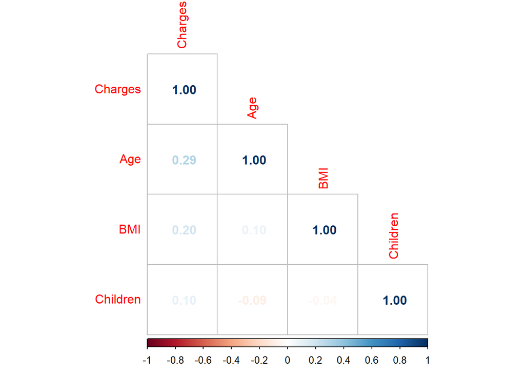

```r
round(cor(samp_numeric),3)%>%
corrplot(method="number",type="lower")
```

## Question 3

Run a regression that includes all independent variables in the data table. Does the model above violate any of the Gauss-Markov assumptions? If so, what are they and what is the solution for correcting?

```r
model1=lm(Charges~.,samp)
summary(model1)
```

```
##
## Call:
## lm(formula = Charges ~ ., data = samp)
##
## Residuals:
##     Min      1Q  Median      3Q     Max
## -8796.5 -2723.0   204.1  2466.7 21269.3
##
## Coefficients:
##                Estimate Std. Error t value Pr(>|t|)
## (Intercept)   -11741.08    3832.74  -3.063  0.00326 **
## Age              266.44      44.95   5.928 1.54e-07 ***
## BMI              288.92     101.42   2.849  0.00598 **
## Female         -1020.15    1286.33  -0.793  0.43081
## Children         268.88     491.34   0.547  0.58621
## Smoker         22869.26    1651.59  13.847  < 2e-16 ***
## WinterSprings   -760.40    1759.85  -0.432  0.66721
## WinterPark      2969.68    2046.28   1.451  0.15183
## Oviedo           551.25    1765.63   0.312  0.75594
## ---
## Signif. codes:  0 '***' 0.001 '**' 0.01 '*' 0.05 '.' 0.1 ' ' 1
##
## Residual standard error: 5239 on 61 degrees of freedom
## Multiple R-squared:  0.8039, Adjusted R-squared:  0.7782
## F-statistic: 31.26 on 8 and 61 DF,  p-value: < 2.2e-16
```

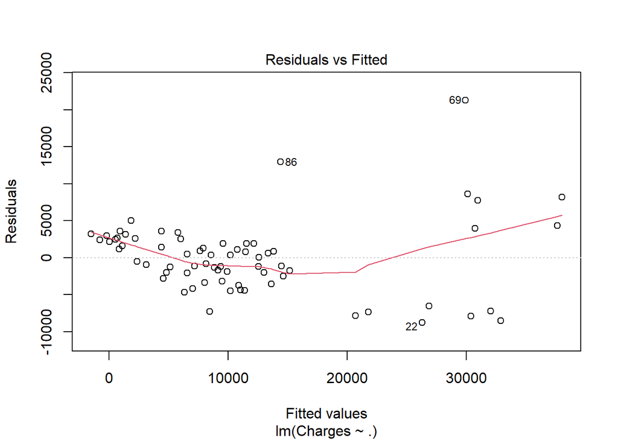

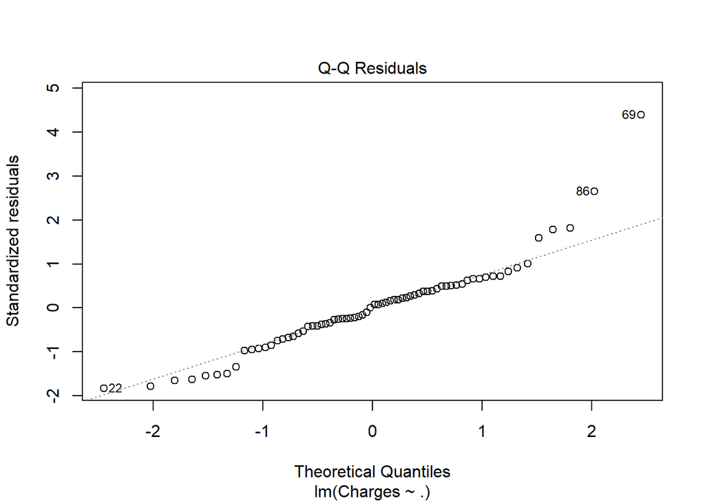

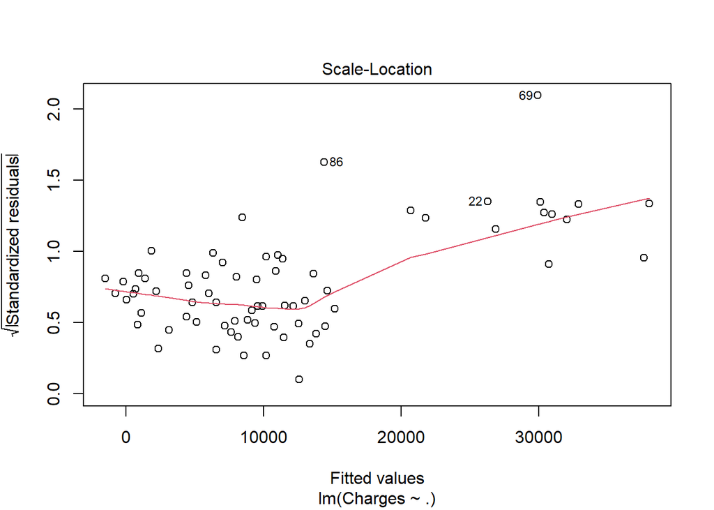

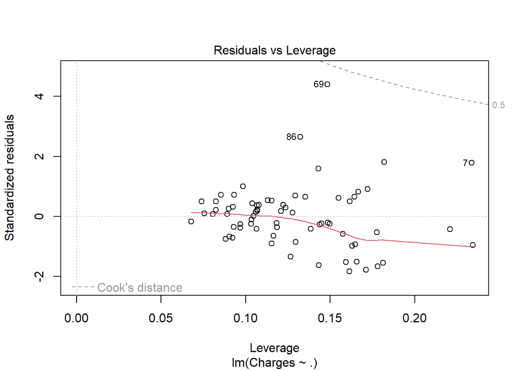

```r
plot(model1)
```

According to the Gauss-Markov Assumptions: 1.) Linearity: The parameters are constant which suggest the model is linear.Solution: examine residual plots for signs of non-linearity.  
2.)Random Disturbance: As the intercept is included there are no errors. 3.)Homoscedasticity: The variance of residuals should remain constant across predicted values. 4.)Heteroskedasticity: Since the spread of the variance the standard deviation is not constant causing it to expand. 5.) Apply to time series

## Question 4

Implement the solutions from question 3, such as data transformation, along with any other changes you wish. Use the sample data and run a new regression. How have the fit measures changed? How have the signs and significance of the coefficients changed?

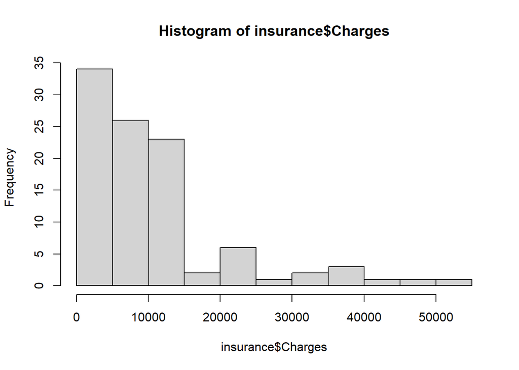

```r
hist(insurance$Charges)
```

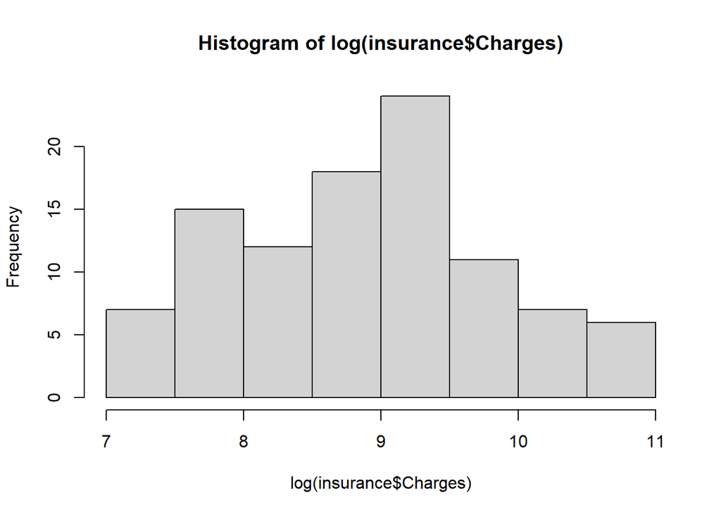

```r
hist(log(insurance$Charges))#after
```

```r
model2=lm(log(Charges)~.-Children,samp)
summary(model2)
```

```
##
## Call:
## lm(formula = log(Charges) ~ . - Children, data = samp)
##
## Residuals:
##     Min      1Q  Median      3Q     Max
## -0.8687 -0.1599  0.0202  0.1150  0.9510
##
## Coefficients:
##                Estimate Std. Error t value Pr(>|t|)
## (Intercept)    6.885183   0.246899  27.887   <2e-16 ***
## Age            0.041515   0.002935  14.144   <2e-16 ***
## BMI            0.005099   0.006639   0.768    0.445
## Female        -0.005248   0.084162  -0.062    0.950
## Smoker         1.633109   0.107495  15.192   <2e-16 ***
## WinterSprings  0.023453   0.115059   0.204    0.839
## WinterPark     0.063946   0.133902   0.478    0.635
## Oviedo         0.026083   0.115490   0.226    0.822
## ---
## Signif. codes:  0 '***' 0.001 '**' 0.01 '*' 0.05 '.' 0.1 ' ' 1
##
## Residual standard error: 0.3431 on 62 degrees of freedom
## Multiple R-squared:  0.8701, Adjusted R-squared:  0.8554
## F-statistic: 59.32 on 7 and 62 DF,  p-value: < 2.2e-16
```